# 01_DEP-subs-prot

Pedro, zagor

2023-09-07

# 1 Libraries

```r
rm(list = ls(all = TRUE))
gc()
```

```
##          used (Mb) gc trigger (Mb) max used (Mb)
## Ncells 526750 28.2    1174817 62.8   660365 35.3
## Vcells 967707  7.4    8388608 64.0  1770629 13.6
```

```r
set.seed(123456)


`%nin%` = Negate(`%in%`)

library(RColorBrewer)


#  if (!require("BiocManager", quietly = TRUE))
#      install.packages("BiocManager")
#
# BiocManager::install("DEP")
# BiocManager::install("fgsea")
# BiocManager::install("GEOquery")
# BiocManager::install("limma", force = TRUE)
# BiocManager::install("BiocGenerics")
#
# install.packages("ggplot2")

library(ggplot2)
library(DEP)
library(magrittr)
library(fgsea)
library(data.table)
library(ggplot2)
library(stats)
# library(GEOquery)
library(limma)
library(BiocGenerics)
```

# 2 Palletes

https://cran.r-project.org/web/packages/viridis/vignettes/intro-to-viridis.html#the-color-scales

https://renenyffenegger.ch/notes/development/languages/R/packages/RColorBrewer/index

https://r-charts.com/color-palettes/#google_vignette

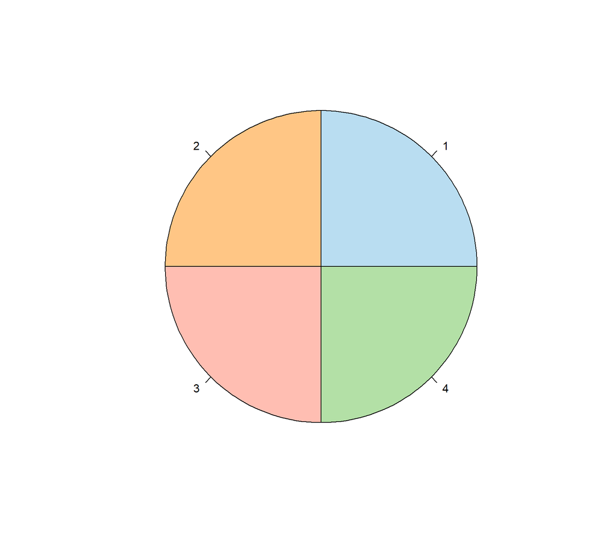

```r
palette1 = paletteer::paletteer_c("ggthemes::Blue", 1)
palette2 = paletteer::paletteer_c("ggthemes::Orange", 1)
palette3 = paletteer::paletteer_c("ggthemes::Red", 1)
palette4 = paletteer::paletteer_c("ggthemes::Green", 1)
palette_groups = c(palette1, palette2, palette3, palette4)

pie(rep(1, length(palette_groups)), col = palette_groups)
```

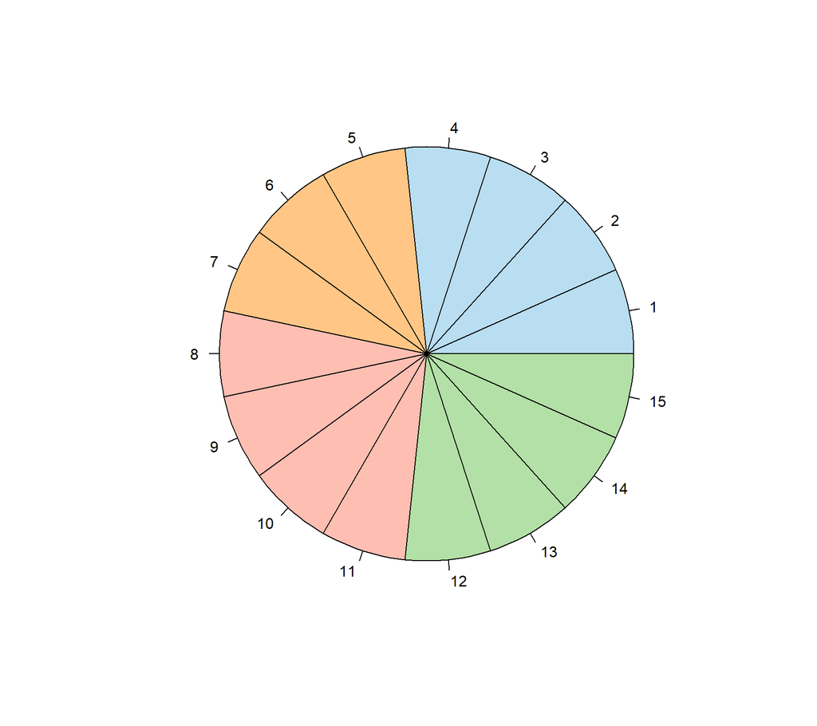

```r
palette_all = c(rep(palette1, 4), rep(palette2, 3), rep(palette3, 4), rep(palette4, 4))
pie(rep(1, length(palette_all)), col = palette_all)
```

# 3 contrasts

see `../input/forComparisons.txt` file

```r
# setwd("C:/Users/maria/Downloads/Fosfoproteome")

fp = file.path('..', 'input')
fn = 'forComparisons.txt'

forComparisons = data.table::fread(file.path(fp, fn), header = TRUE)
data.table::setDF(forComparisons)

selection = cbind(c(forComparisons$stress, forComparisons$mock),
                  c(forComparisons$timeS, forComparisons$timeC))
selection = as.data.frame(selection[!duplicated(selection), ])
colnames(selection) = c('Treatment', 'SamplingTime')
# add leading zero to sort better
# selection$SamplingTime = sprintf('%05d', as.numeric(selection$SamplingTime))
selection$TreatmentxSamplingTime = paste(selection$Treatment, selection$SamplingTime, sep = '_')


selection = selection[order(selection$SamplingTime, selection$Treatment), ]
# print(selection)

# forComparisons$timeS = sprintf('%05d', as.numeric(forComparisons$timeS))
# forComparisons$timeC = sprintf('%05d', as.numeric(forComparisons$timeC))
```

# 4 input

## 4.1 data

```r
fn = 'AllProteins_PhosphoLYCES_new_.xlsx'

ignore = 1:3

Prot = openxlsx::read.xlsx(xlsxFile = file.path(fp, fn),
                           sheet = 1,
                           startRow = 1,
                           colNames = TRUE,
                           rowNames = FALSE,
                           detectDates = FALSE,
                           skipEmptyRows = TRUE,
                           skipEmptyCols = TRUE,
                           rows = NULL,
                           cols = NULL,
                           check.names = FALSE,
                           sep.names = ".",
                           namedRegion = NULL,
                           na.strings = "NA",
                           fillMergedCells = FALSE
                           )
rownames(Prot) = Prot[, 1]
Prot = Prot[, -ignore]
Prot = t(Prot)

# ### Importing the reads:
#
# fn = 'Prot_abundances_ITAG41_forR.csv'
#
# Prot <- as.data.frame(read.csv2(file.path(fp, fn))) #load your archive
# rownames(Prot) <- Prot[,1] #selection as rownames your genesID column
# Prot <- Prot[,-1] #deletion geneID column as is already rowname
```

## 4.2 phenodata

```r
fn = 'Phenodata Phosphoprotemoics.txt'

pheno = data.table::fread(file.path(fp, fn), header = TRUE)
data.table::setDF(pheno)



all(colnames(Prot) == pheno$SampleName)
```

```
## [1] TRUE
```

```r
# add leading zero to sort better
# pheno$Min = sprintf('%05d', pheno$Min)
pheno$Min = pheno$Time
```

set 0 to NA

- notice that sometimes samples are names as `_1h_` and sometimes as `_1_h`; same goer for min

```r
# colnames(Prot) = paste(pheno$Condition, pheno$Min, sep = '_')
# all(colnames(Prot) %in% selection$TreatmentxSamplingTime)


table(is.na(Prot))
```

```
##
## FALSE
## 56610
```

```r
table(Prot == 0)
```

```
##
## FALSE  TRUE
## 56188   422
```

```r
Prot[Prot == 0] = NA
table(Prot == 0)
```

```
##
## FALSE
## 56188
```

```r
table(is.na(Prot))
```

```
##
## FALSE  TRUE
## 56188   422
```

```r
typeof(Prot)
```

```
## [1] "double"
```

```r
myProteomics = as.matrix(Prot)

cn = colnames(myProteomics)
rn = rownames(myProteomics)
typeof(myProteomics)
```

```
## [1] "double"
```

```r
range(myProteomics, na.rm = TRUE)
```

```
## [1] 1.040278e-02 9.138573e+09
```

```r
myProteomics0 = myProteomics
myProteomics0[is.na(myProteomics0)] = 0
```

# 5 log transformation

## 5.1 Density plots

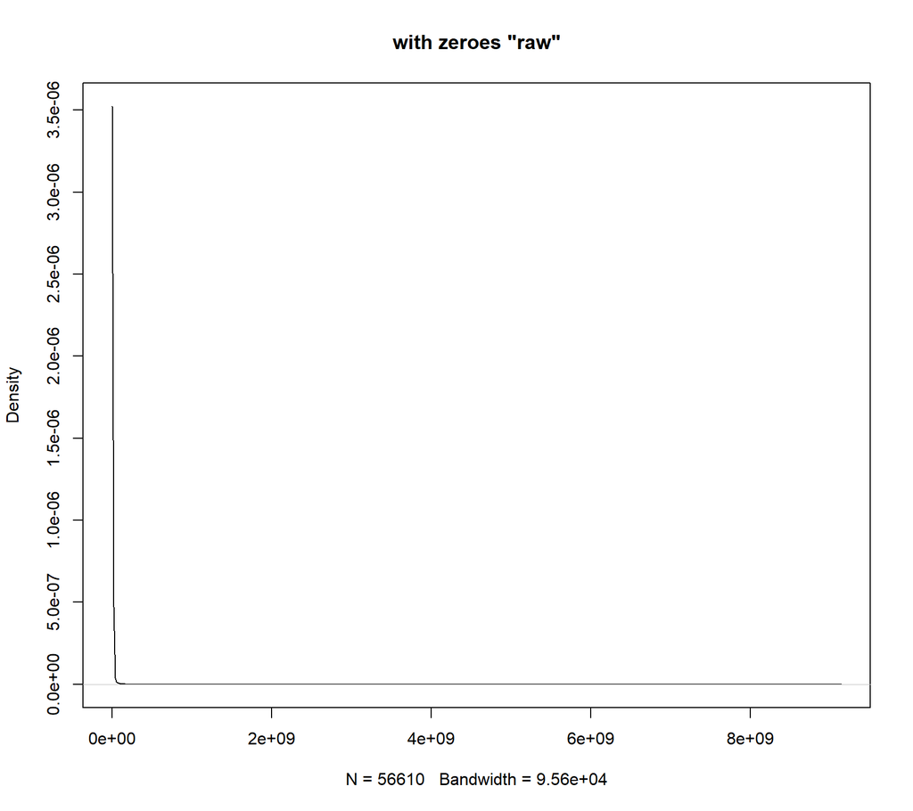

```r
plot(density(myProteomics0),  main = 'with zeroes "raw"')
```

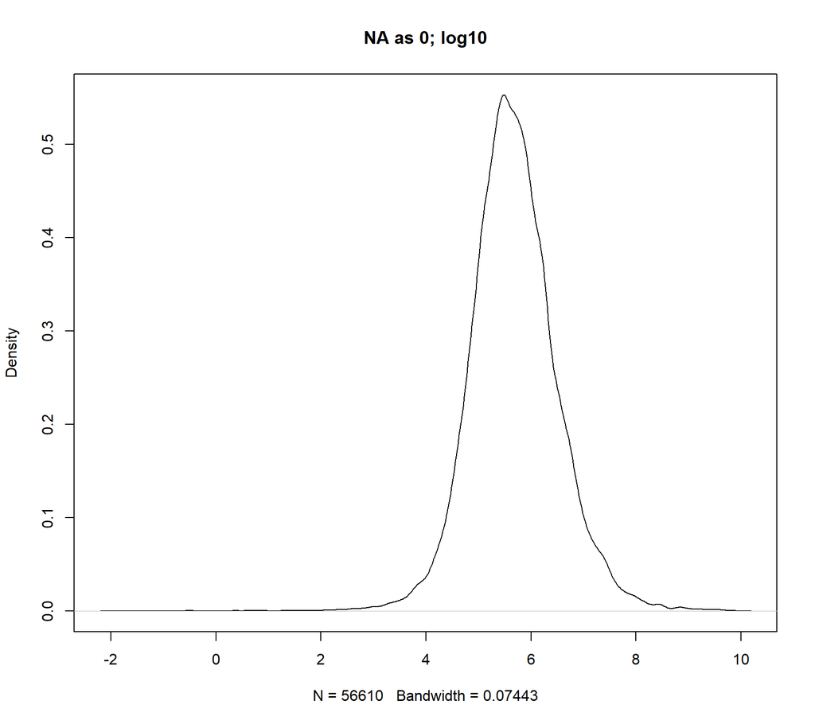

```r
plot(density(log(myProteomics0, 10)), main = 'NA as 0; log10')
```

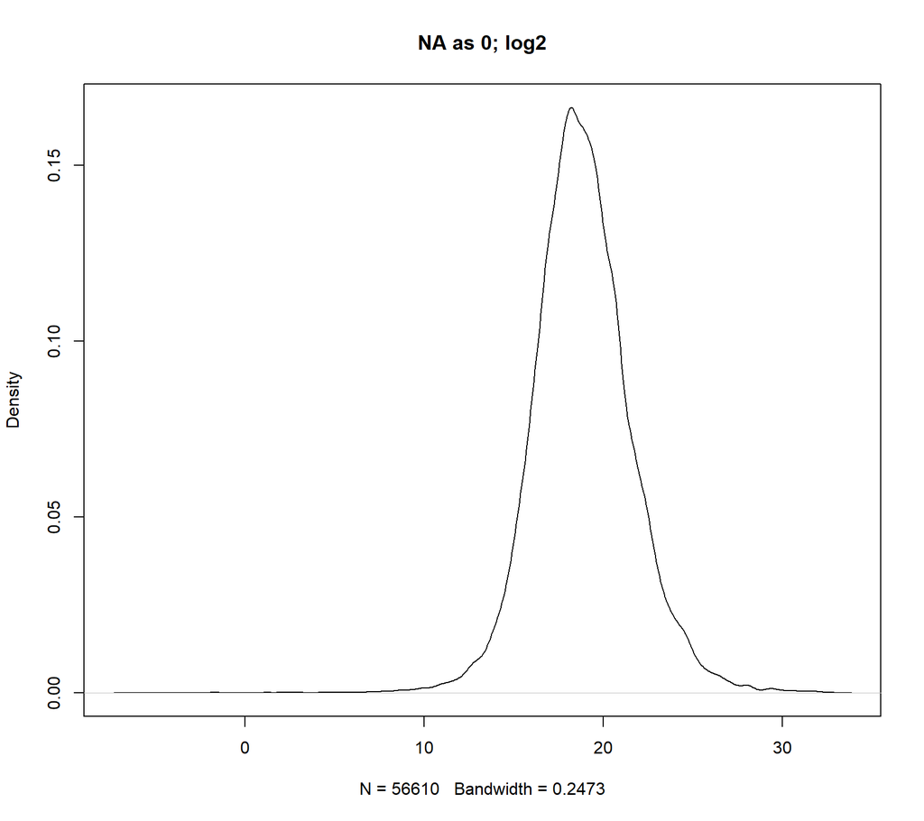

```r
plot(density(log(myProteomics0, 2)), main = 'NA as 0; log2')
```

```r
df = data.frame(cbind(rn, myProteomics))
typeof(df)
```

```
## [1] "list"
```

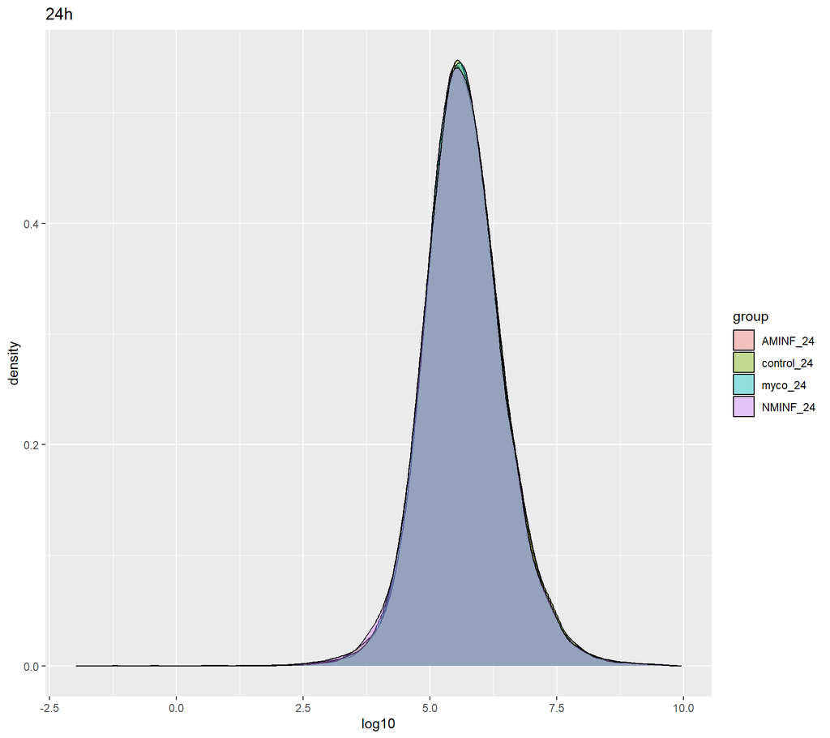

```r
colnames(df)[1] = 'pID'
P.l = tidyr::gather(df, group, value, colnames(df)[2]:colnames(df)[ncol(df)], factor_key = FALSE)


P.l$group = as.factor(gsub('_1$|_2$|_3$|_4$', '', P.l$group))
P.l$log10 = log(as.numeric(P.l$value), 10)
P.l$log2 = log(as.numeric(P.l$value), 2)

#Again the library bc I always have problems with ggplot
# library(ggplot2)

# for(i in unique(pheno$Condition)) {
#
#   subset = P.l[grep(i, P.l$group), ]
#   subset$group = droplevels(subset$group)
#
#   g = ggplot(data = subset, aes(x = log10, group = group, fill = group)) +
#     geom_density(adjust=1.5, alpha=.4) +
#     ggtitle(i)
#
#   plot(g)
#
# }

  g = ggplot(data = P.l, aes(x = log10, group = group, fill = group)) +
    geom_density(adjust=1.5, alpha=.4) +
    scale_color_manual(values=palette_groups) +
    ggtitle('24h')

  plot(g)
```

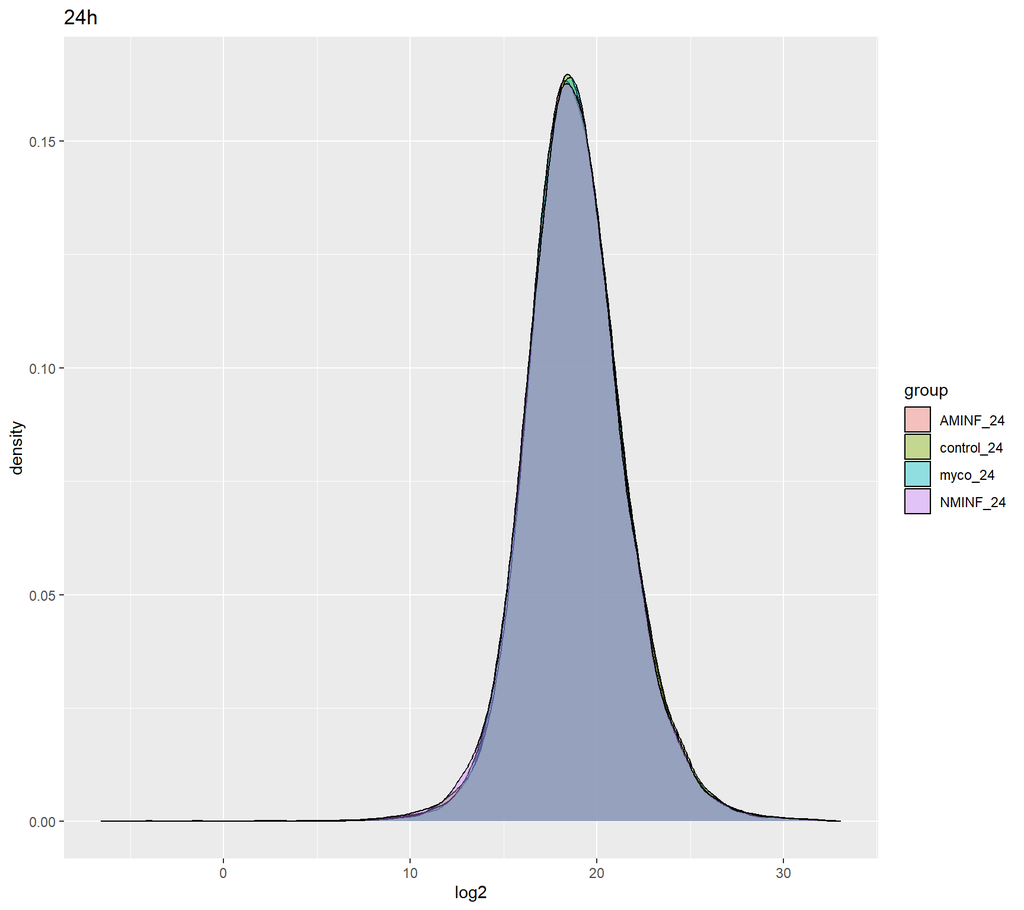

```r
#
# for(i in unique(pheno$Condition)) {
#
#   subset = P.l[grep(i, P.l$group), ]
#   subset$group = droplevels(subset$group)
#
#   g = ggplot(data = subset, aes(x = log2, group = group, fill = group)) +
#     geom_density(adjust=1.5, alpha=.4) +
#     ggtitle(i)
#
#   plot(g)
#
# }


  g = ggplot(data = P.l, aes(x = log2, group = group, fill = group)) +
    geom_density(adjust=1.5, alpha=.4) +
        scale_color_manual(values=palette_groups) +
    ggtitle('24h')

  plot(g)
```

```r
#
# }
```

# 6 Differential Enrichment analysis of Proteomics data

DEP https://bioconductor.org/packages/release/bioc/vignettes/DEP/inst/doc/DEP.html

- log2/log10 values
- no additional normalisation
- no imputation (when needed see https://bioconductor.org/packages/release/bioc/vignettes/DEP/inst/doc/MissingValues.html#data-imputation-of-missing-data)
- Protein-wise linear models combined with empirical Bayes statistics are used for the differential enrichment analysis (or differential expression analysis)
- The test_diff function introduced here uses limma and automatically generates the contrasts to be tested
- For the contrasts generation, the control sample has to be specified. Additionally, the types of contrasts to be produced need to be indicated, allowing the generation of all possible comparisons (“all”) or the generation of contrasts of every sample versus control (“control”). Alternatively, the user can manually specify the contrasts to be tested (type = “manual”), which need to be specified in the argument test.

## 6.1 Create objects

```r
# BiocManager::install("BiocStyle")
#
# suppressPackageStartupMessages({
# library("BiocStyle")
# library("DEP")
# library("dplyr")
# })
# library("dplyr")
# library("BiocStyle")
# library("dplyr")
# library("magrittr")
# library("ggplot2")

# table(is.na(myProteomics))
# table(myProteomics == 0)


LFQ_columns = 1:ncol(myProteomics)
data_unique = myProteomics
experimental_design = as.data.frame(colnames(myProteomics))
colnames(experimental_design) = 'label'
# tmp = (strsplit(colnames(myProteomics), '_h|_min|h|min'))
# tmp = as.data.frame(do.call(rbind, tmp))
# tmp = tmp[, 1]
# experimental_design$condition = tmp
experimental_design$condition = paste(pheno$Condition, pheno$Time,  sep = '_')
rep = 4

#experimental_design$replicate = rep(1:rep, times = ncol(myProteomics)/rep) #PROBLEMMMS HERE BC IN ONE OF THE TREATMENTS I ONLY HAVE 4 REPLICATES
ex_d = rep(1:rep, times = rep)
#Bc I have only 3 replicates in mycorrhiza. You add the fourth and then you eliminate it (position 8)
experimental_design$replicate = ex_d[-8]

tail(experimental_design)
```

```
##         label condition replicate
## 10 NMINF_24_3  NMINF_24         3
## 11 NMINF_24_4  NMINF_24         4
## 12 AMINF_24_1  AMINF_24         1
## 13 AMINF_24_2  AMINF_24         2
## 14 AMINF_24_3  AMINF_24         3
## 15 AMINF_24_4  AMINF_24         4
```

```r
df = as.data.frame(myProteomics)
df$Protein.IDs = rownames(myProteomics)
df$Protein.names = rownames(myProteomics)
data_unique = DEP::make_unique(proteins = df, ids = "Protein.IDs", names = "Protein.names")
```

## 6.2 Data.frame to SummarizedExperiment object conversion using an experimental design

make_se {DEP} - creates a SummarizedExperiment object based on two data.frames: the protein table and experimental design.

Looks like that automatic transformation is log2

```r
# Are there any duplicated names?
data_unique$name %>% duplicated() %>% any()
```

```
## [1] FALSE
```

```r
# Generate a SummarizedExperiment object using an experimental design
data_se = make_se(data_unique, LFQ_columns, experimental_design)
data_se
```

```
## class: SummarizedExperiment
## dim: 3774 15
## metadata(0):
## assays(1): ''
## rownames(3774): Solyc12g015710.2.1 Solyc07g065510.4.1 ...
##   Solyc01g096240.4.1 Solyc09g010420.4.1
## rowData names(4): Protein.IDs Protein.names name ID
## colnames(15): control_24_1 control_24_2 ... AMINF_24_3 AMINF_24_4
## colData names(4): label ID condition replicate
```

```r
dim(as.data.frame(data_se@assays@data@listData))
```

```
## [1] 3774   15
```

```r
dim(myProteomics)
```

```
## [1] 3774   15
```

```r
# check log transformation
table(as.data.frame(data_se@assays@data@listData) == log(myProteomics, 2))
```

```
##
##  TRUE
## 56188
```

## 6.3 Plot protein overlap between samples

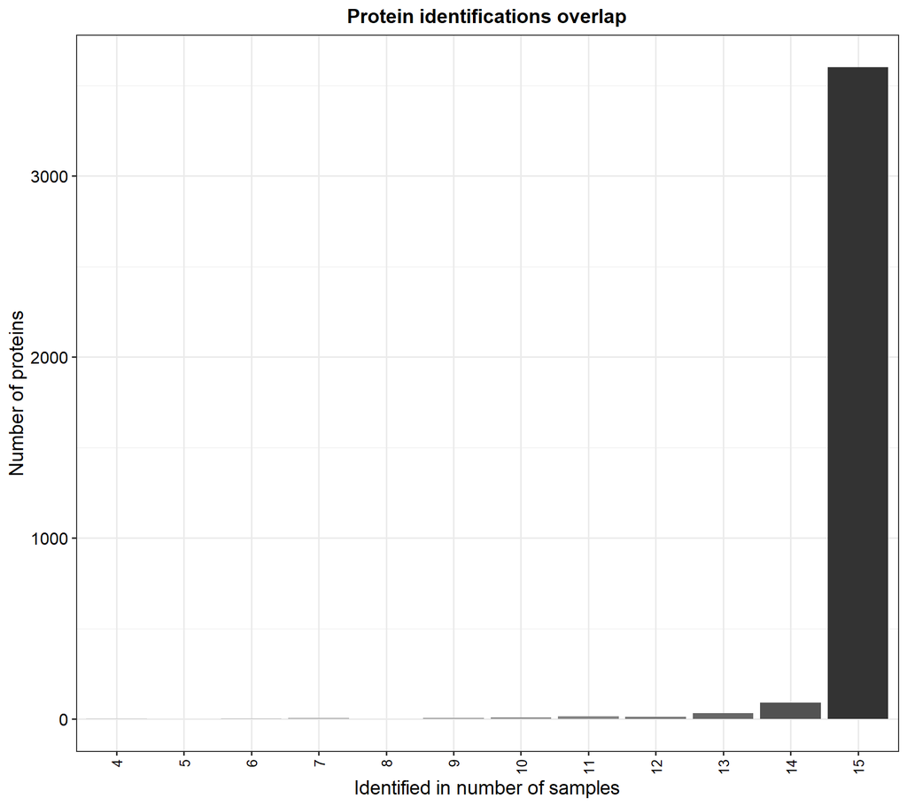

```r
plot_frequencyX = function (se, plot = TRUE)
{
    assertthat::assert_that(inherits(se, "SummarizedExperiment"),
        is.logical(plot), length(plot) == 1)

    df = SummarizedExperiment::assay(se) %>% data.frame() %>% tibble::rownames_to_column() %>%
        tidyr::gather(ID, bin, -rowname) %>% dplyr::mutate(bin = ifelse(is.na(bin),
        0, 1))

    table(df$ID, df$bin)

    stat = df %>% dplyr::group_by(rowname) %>% dplyr::summarize(sum = sum(bin))

    table = table(stat$sum) %>% data.frame()

    p = ggplot(table, aes(x = Var1, y = Freq, fill = Var1)) +
        geom_col() + scale_colour_viridis_d(begin = 0, end = 1) +
        labs(title = "Protein identifications overlap",
            x = "Identified in number of samples", y = "Number of proteins") +
        theme_DEP2() + theme(legend.position = "right") + theme(axis.text.x = element_text(size = 14))

    if (plot) {
        return(p)
    }
    else {
        df = as.data.frame(table)
        colnames(df) = c("samples", "proteins")
        return(df)
    }
}

plot_frequency(data_se) + theme(axis.text.x = element_text(size = 10))
```

## 6.4 Filter on missing values

```r
# filter_missval filters a proteomics dataset based on missing values. The dataset is filtered for proteins that have a maximum of 'thr' missing values in at least one condition.
data_filt = filter_missval(data_se, thr = 0)

data_filt
```

```
## class: SummarizedExperiment
## dim: 3752 15
## metadata(0):
## assays(1): ''
## rownames(3752): Solyc00g500020.1.1 Solyc00g500022.1.1 ...
##   Solyc12g100160.3.1 Solyc12g100200.2.1
## rowData names(4): Protein.IDs Protein.names name ID
## colnames(15): control_24_1 control_24_2 ... AMINF_24_3 AMINF_24_4
## colData names(4): label ID condition replicate
```

### 6.4.1 Plot protein numbers

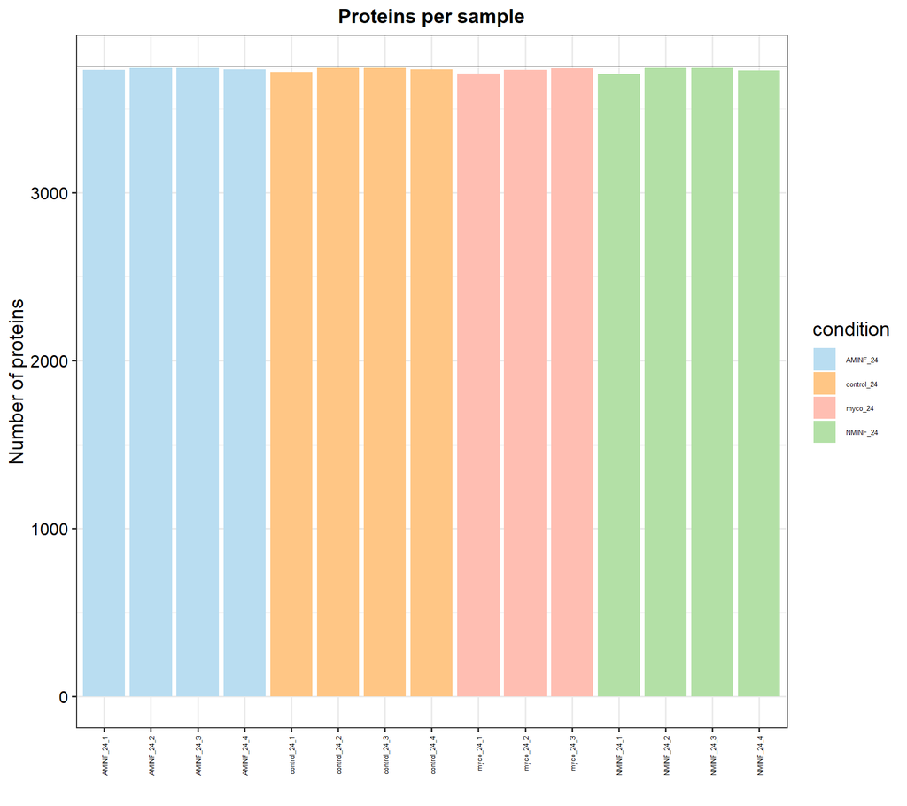

```r
## ----plot_data, fig.width = 4, fig.height = 4---------------------------------
# Plot a barplot of the number of identified proteins per samples
plot_numbers(data_filt) + theme(axis.text.x = element_text(size = 5)) + theme(legend.text = element_text(size = 5)) + scale_fill_manual(values=palette_groups)
```

### 6.4.2 Plot protein coverage

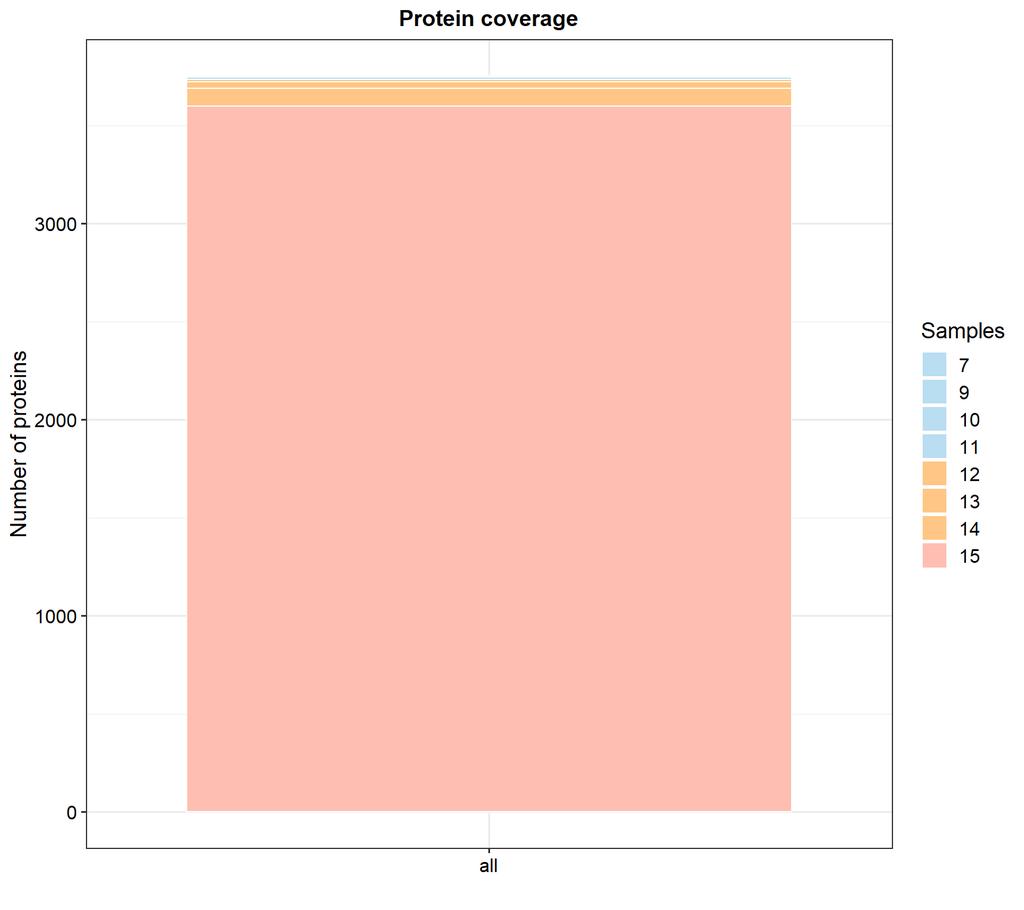

```r
## ----plot_data2, fig.width = 3, fig.height = 4--------------------------------
# Plot a barplot of the protein identification overlap between samples
# plot_coverage(data_filt)
## ----plot_data2, fig.width = 3, fig.height = 4--------------------------------
# Plot a barplot of the protein identification overlap between samples
plot_coverage(data_filt) + scale_fill_manual(values=palette_all)
```

### 6.4.3 Plot a heatmap of proteins with missing values

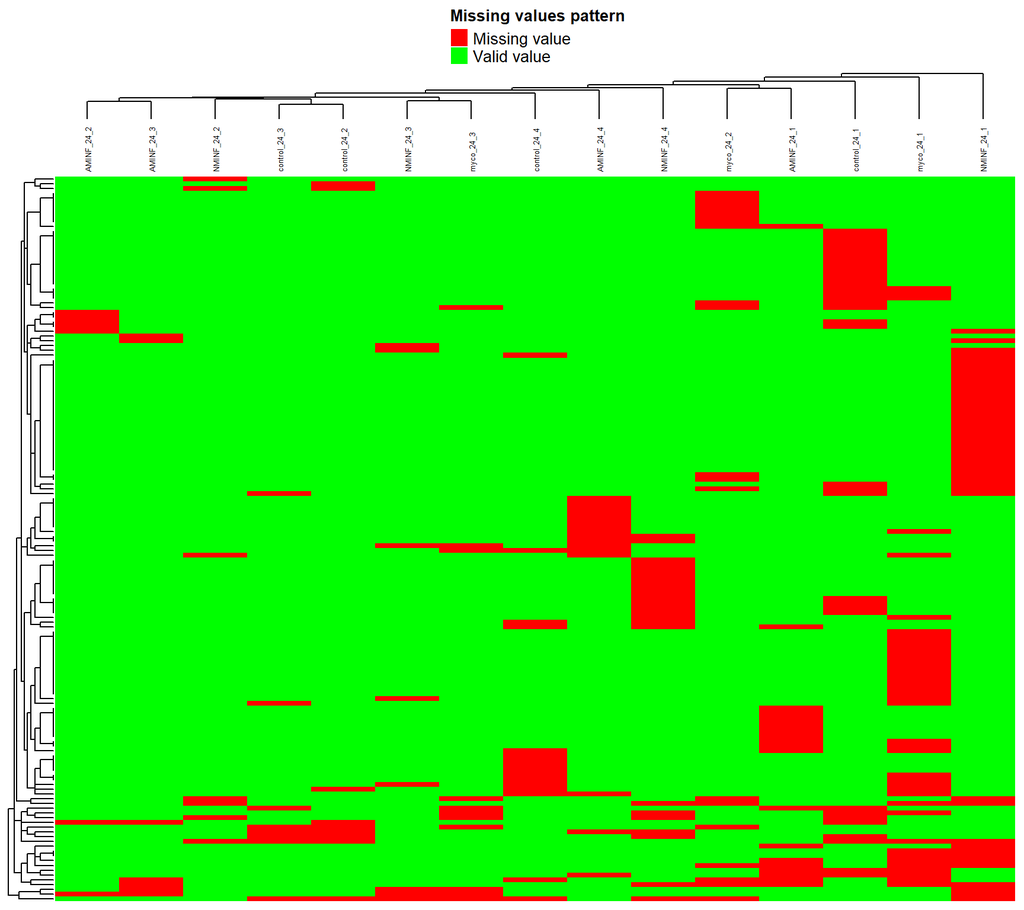

```r
plot_missval = function (se)
{
    assertthat::assert_that(inherits(se, "SummarizedExperiment"))
    se_assay <- SummarizedExperiment::assay(se)

    if (!any(is.na(se_assay))) {
        stop("No missing values in '", deparse(substitute(se)),
            "'", call. = FALSE)
    }

    df <- se_assay %>% data.frame(.)
    missval <- df[apply(df, 1, function(x) any(is.na(x))), ]
    missval <- ifelse(is.na(missval), 0, 1)

    ht2 = ComplexHeatmap::Heatmap(missval,
                  col = c("red", "green"),
        column_names_side = "top",
        show_row_names = FALSE,
        show_column_names = TRUE,
        name = "Missing values pattern",
        column_names_gp = grid::gpar(fontsize = 5),
        heatmap_legend_param = list(at = c(0, 1), labels = c("Missing value", "Valid value")))

    ComplexHeatmap::draw(ht2, heatmap_legend_side = "top")
}


plot_missval(data_filt)
```

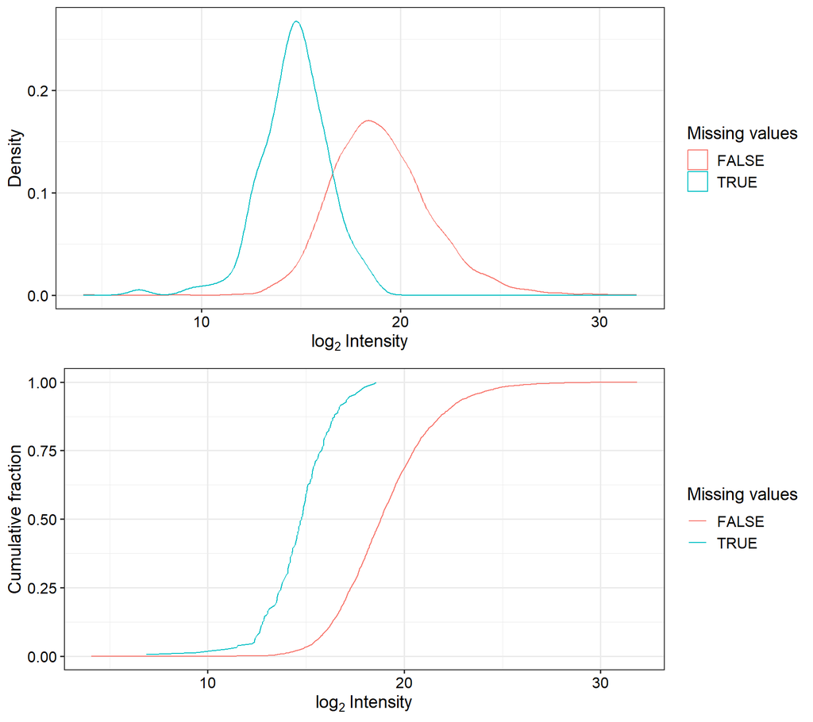

```r
plot_detect(data_filt)
```

## 6.5 Visualize normalization

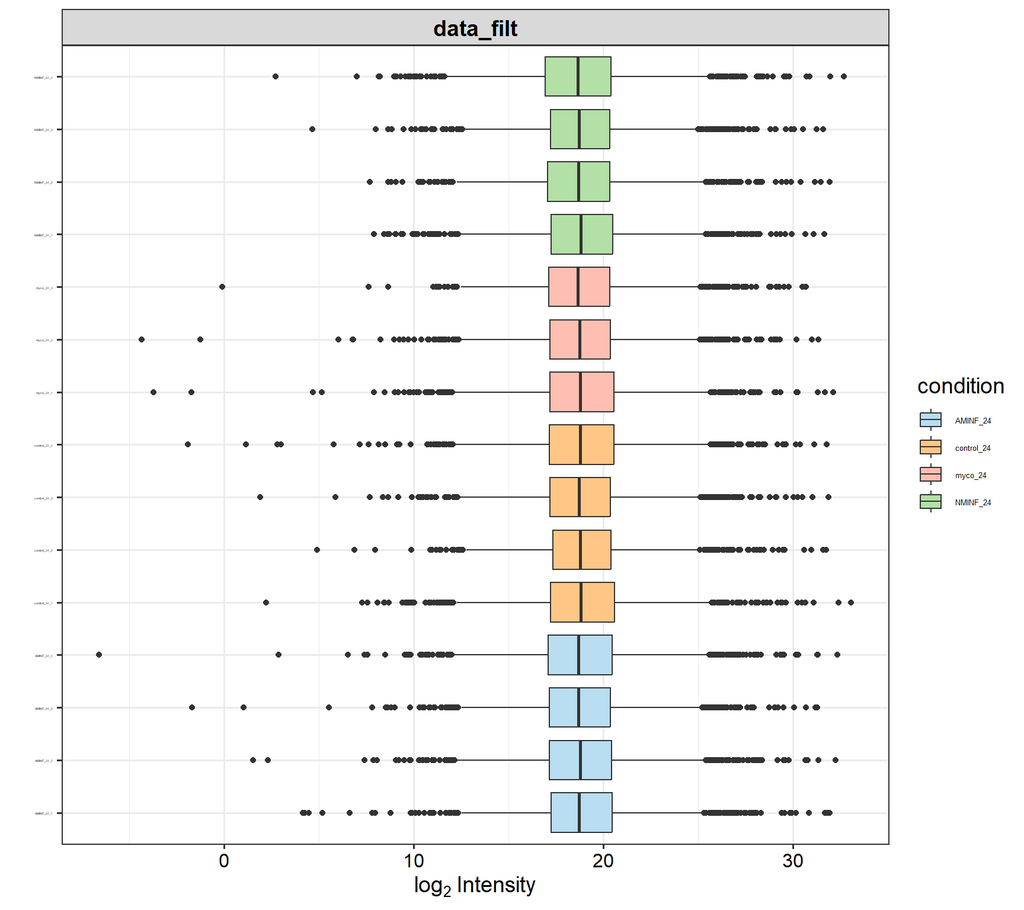

```r
## ----normalize----------------------------------------------------------------
# Normalize the data
# data_norm = normalize_vsn(data_filt)
# # as.data.frame(preprocessCore::normalize.quantiles(as.matrix(df)))
# meanSdPlot(data_norm)
# range(data_norm@assays@data[[1]])
# range(data_filt@assays@data[[1]])
## ----plot_norm, fig.width = 4, fig.height = 5---------------------------------
# Visualize normalization by boxplots for all samples before and after normalization
# plot_normalization(data_filt, data_norm)


plot_normalization(data_filt) + theme(axis.text.y = element_text(size = 2)) + theme(legend.text = element_text(size = 5)) + scale_fill_manual(values=palette_groups) + geom_boxplot(outlier.size = 0.01)
```

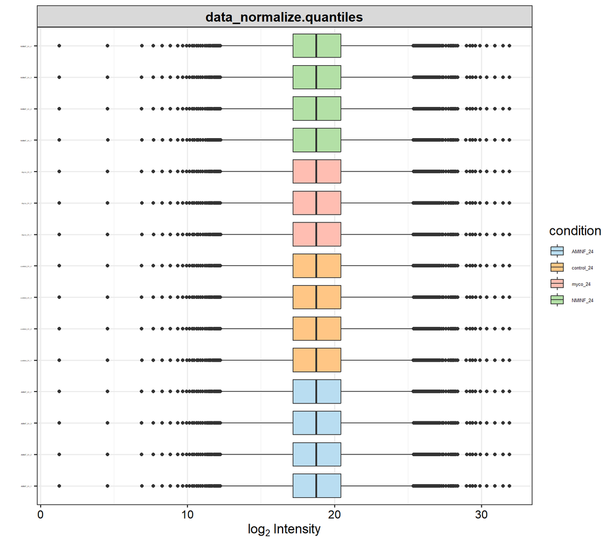

```r
data_normalize.quantiles = data_filt
data_normalize.quantiles@assays@data[[1]] = as.data.frame(preprocessCore::normalize.quantiles(as.matrix(data_normalize.quantiles@assays@data[[1]])))
plot_normalization(data_normalize.quantiles) + theme(axis.text.y = element_text(size = 2)) + theme(legend.text = element_text(size = 5)) +  scale_fill_manual(values = palette_groups) + geom_boxplot(outlier.size = 0.01)
```

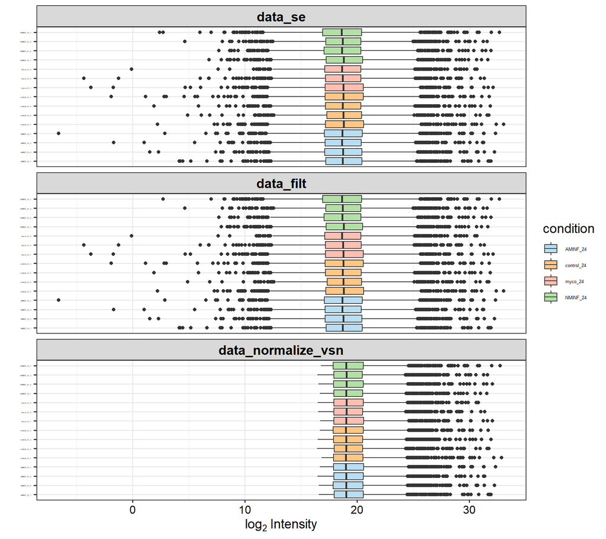

```r
data_normalize_vsn = normalize_vsn(data_filt)
plot_normalization(data_se, data_filt, data_normalize_vsn) + theme(axis.text.y = element_text(size = 2)) + theme(legend.text = element_text(size = 5)) + scale_fill_manual(values=palette_groups) + geom_boxplot(outlier.size = 0.01)
```

```r
# data_norm@assays@data[[1]] = as.data.frame(preprocessCore::normalize.quantiles(as.matrix(data_unique[, LFQ_columns])))
# plot_normalization(data_filt, data_norm)
# plot_normalization(data_norm)


# data_norm = data_filt
# DATA ALREADY FILTERED, NORMALISED, preprocessed for sure
data_norm = data_filt
```

### 6.5.1 Plot the density of expression values for multiple arrays on the same plot

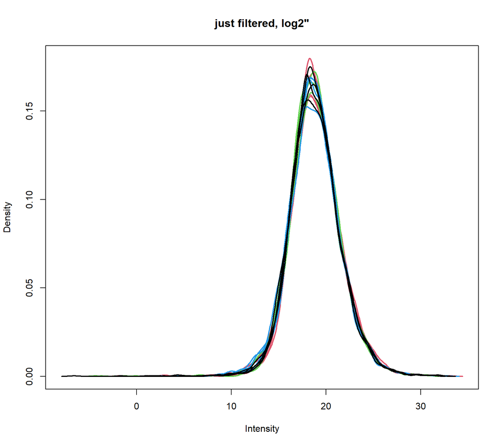

```r
limma::plotDensities(data_filt@assays@data[[1]], main = 'just filtered, log2"',
                     group = experimental_design$condition, legend = FALSE)
```

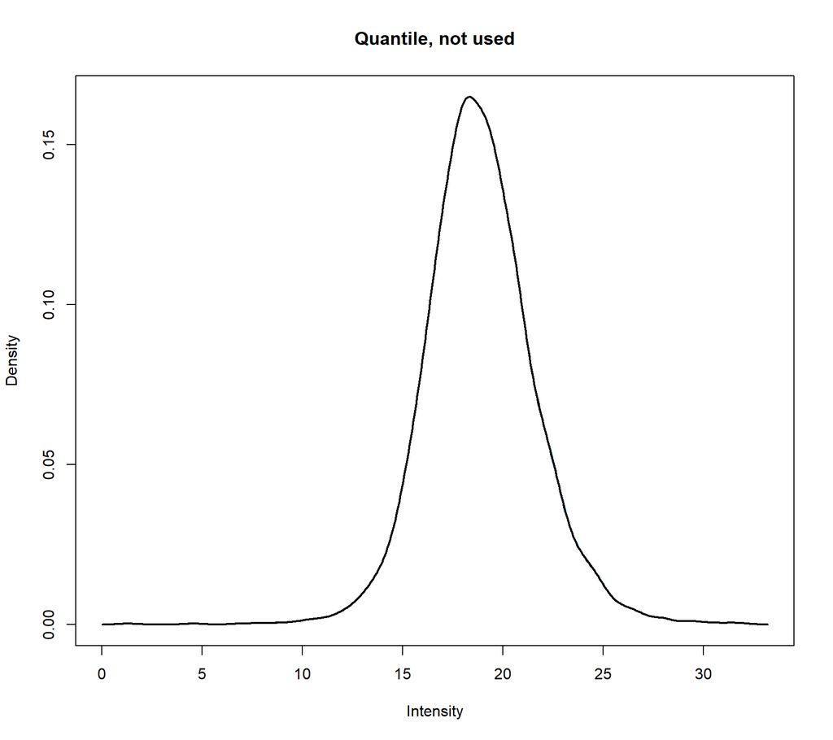

```r
limma::plotDensities(data_normalize.quantiles@assays@data[[1]], main = 'Quantile, not used',
                     group = experimental_design$condition, legend = FALSE)
```

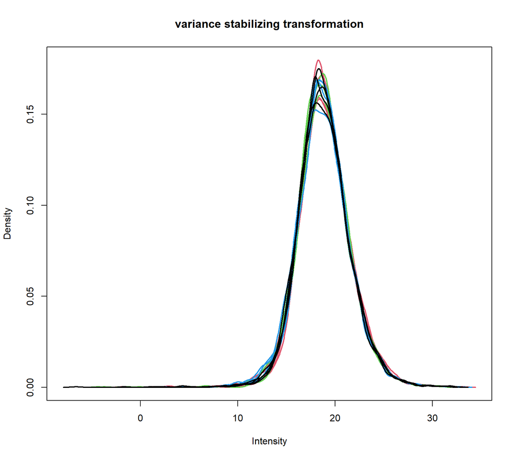

```r
limma::plotDensities(data_norm@assays@data[[1]], main = 'variance stabilizing transformation',
                     group = experimental_design$condition, legend = FALSE)
```

```r
# all (log(myProteomics, 2) == data_filt@assays@data[[1]])
table(data_filt@assays@data[[1]] != data_norm@assays@data[[1]])
```

```
##
## FALSE
## 56007
```

## 6.6 Contrasts

```r
# Test manually defined comparisons
# data_diff_manual = test_diff(data_norm,
#                              type = "manual",
#                              test = c("Nm_Wounding_30_vs_Nm_Mock_30"))
# read from table
mytest = unique(paste0(paste(forComparisons[, 1], forComparisons[, 2], sep = '_'),
'_vs_',
paste(forComparisons[, 3], forComparisons[, 4], sep = '_')))
# data_diff_manual = test_diff(data_norm,
#                              type = "manual",
#                              test = mytest[1])



data_diff_manual = test_diff(data_norm,
                              type = "manual",
                              test = mytest)






## ----add_reject---------------------------------------------------------------
# Denote significant proteins based on user defined cutoffs

dep = add_rejections(data_diff_manual, alpha = 0.05)# lfc = log2(1.5))

rs = rowSums(data_norm@assays@data[[1]])
table(is.na(rs))
```

```
##
## FALSE  TRUE
##  3600   152
```

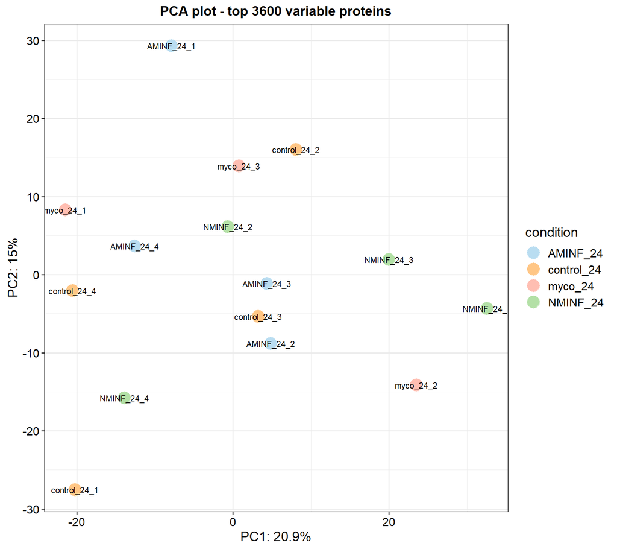

```r
m = sum(!is.na(rs))

plot_pca(dep, x = 1, y = 2, point_size = 6, indicate = "condition", label = TRUE, n = m) + scale_color_manual(values=palette_groups) # n = nrow(dep)
```

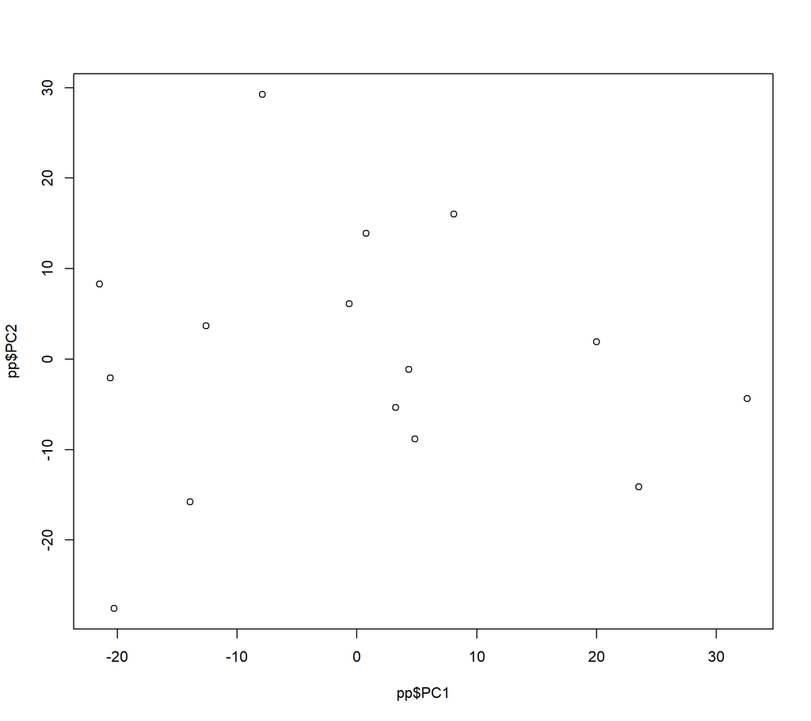

```r
pp = plot_pca(dep, x = 1, y = 2, point_size = 6, indicate = "condition", label = TRUE, n = m, plot = FALSE)
plot(pp$PC1, pp$PC2)
```

```r
# par(mar=c(5.1, 4.1, 4.1, 10.1), xpd=TRUE)
#
# for (i in unique(forComparisons$timeS)) {
#
#   ind = grep(i, pp$condition)
#   subset = pp[ind, ]
#
#   plot(subset$PC1,
#        subset$PC2,
#        col = rep(c("#02401B", "#7294D4", "#972D15", "#FDD262"), each = 3),
#        pch = 19,
#        main = paste("PCA Scatterplot:", i, 'min'),
#        xlab="PC1",
#        ylab="PC2")
#
#   legend(
#     "right",
#          inset=c(-0.75, -0.5),
#          legend = unique(subset$condition),
#          col = c("#02401B", "#7294D4", "#972D15", "#FDD262"),
#          pch = 19,
#          cex = 0.95,
#          )
#
# }
```

## 6.7 Plot Gower’s distance matrix

Gower’s distance is computed as the average of partial dissimilarities across individuals.

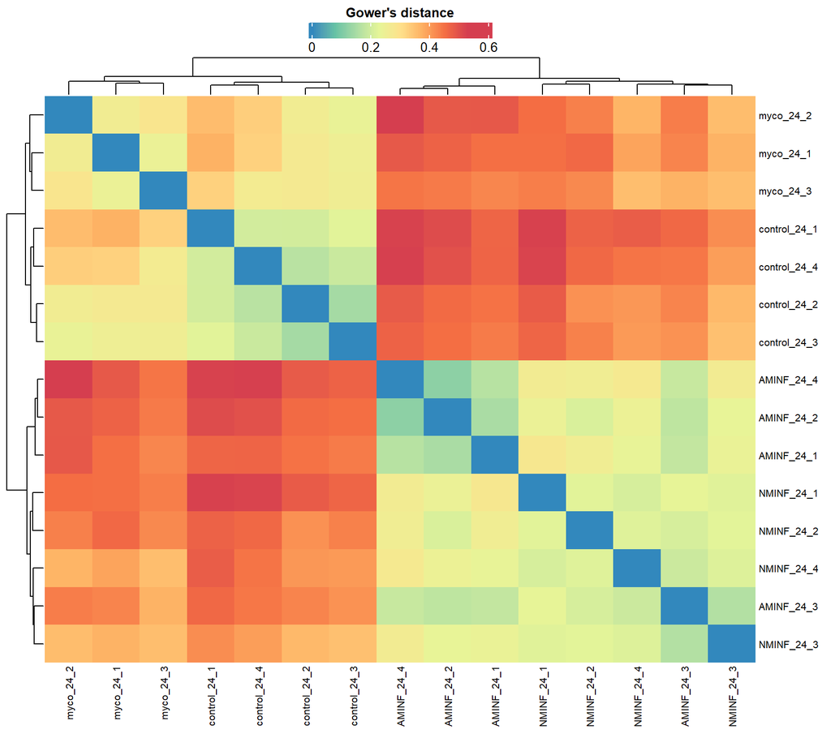

```r
plot_dist(dep, significant = TRUE, pal = "Spectral", font_size = 8)
```

## 6.8 Plot a heatmap of all significant proteins

```r
plot_heatmapX = function (dep,
                          type = c("contrast", "centered"),
                          kmeans = FALSE,
                          k = 6,
                          col_limit = 6,
                          indicate = NULL,
                          clustering_distance = c("euclidean",
                                                  "maximum",
                                                  "manhattan",
                                                  "canberra",
                                                  "binary",
                                                  "minkowski",
                                                  "pearson",
                                                  "spearman",
                                                  "kendall",
                                                  "gower"),
                          row_font_size = 6,
                          col_font_size = 10,
                          plot = TRUE,
                          column_split,
                          ...)
{
    if (is.integer(k))
        k <- as.numeric(k)
    if (is.integer(col_limit))
        col_limit <- as.numeric(col_limit)
    if (is.integer(row_font_size))
        row_font_size <- as.numeric(row_font_size)
    if (is.integer(col_font_size))
        col_font_size <- as.numeric(col_font_size)

    assertthat::assert_that(inherits(dep, "SummarizedExperiment"),
        is.character(type), is.logical(kmeans), is.numeric(k),
        length(k) == 1, is.numeric(col_limit), length(col_limit) ==
            1, is.numeric(row_font_size), length(row_font_size) ==
            1, is.numeric(col_font_size), length(col_font_size) ==
            1, is.logical(plot), length(plot) == 1)

    type <- match.arg(type)
    clustering_distance <- match.arg(clustering_distance)

    row_data <- SummarizedExperiment::rowData(dep, use.names = FALSE)
    col_data <- SummarizedExperiment::colData(dep) %>% as.data.frame()

    if (any(!c("label", "condition", "replicate") %in%
        colnames(col_data))) {
        stop(paste0("'label', 'condition' and/or 'replicate' columns are not present in '",
            deparse(substitute(dep)), "'"), call. = FALSE)
    }

    if (length(grep("_diff", colnames(row_data))) < 1) {
        stop(paste0("'[contrast]_diff' columns are not present in '",
            deparse(substitute(dep)), "'.\nRun test_diff() to obtain the required columns."),
            call. = FALSE)
    }

    if (!"significant" %in% colnames(row_data)) {
        stop(paste0("'significant' column is not present in '",
            deparse(substitute(dep)), "'.\nRun add_rejections() to obtain the required column."),
            call. = FALSE)
    }

    if (!is.null(indicate) & type == "contrast") {
        warning("Heatmap annotation only applicable for type = 'centered'",
            call. = FALSE)
    }

    if (!is.null(indicate) & type == "centered") {
        ha1 <- get_annotation(dep, indicate)
    } else {
        ha1 <- NULL
    }

    # filtering sig proteins
    filtered <- dep[row_data$significant, ]

    if (any(is.na(SummarizedExperiment::assay(filtered)))) {
        warning("Missing values in '", deparse(substitute(dep)),
            "'. ", "Using clustering_distance = 'gower'",
            call. = FALSE)
        clustering_distance <- "gower"
        obs_NA <- TRUE
    } else {
        obs_NA <- FALSE
    }

    if (type == "centered") {
        rowData(filtered)$mean <- rowMeans(SummarizedExperiment::assay(filtered), na.rm = TRUE)
        df <- assay(filtered) - rowData(filtered, use.names = FALSE)$mean
    }

    if (type == "contrast") {
        df <- SummarizedExperiment::rowData(filtered, use.names = FALSE) %>% data.frame() %>%
            tibble::column_to_rownames(var = "name") %>% dplyr::select(ends_with("_diff"))
        colnames(df) <- gsub("_diff", "", colnames(df)) %>%
            gsub("_vs_", " vs ", .)
        df <- as.matrix(df)
    }

    if (kmeans & obs_NA) {
        warning("Cannot perform kmeans clustering with missing values",
            call. = FALSE)
        kmeans <- FALSE
    }

    if (kmeans & !obs_NA) {
        set.seed(1)
        df_kmeans <- kmeans(df, k)
        if (type == "centered") {
            order <- data.frame(df) %>% cbind(., cluster = df_kmeans$cluster) %>%
                mutate(row = apply(.[, seq_len(ncol(.) - 1)],
                  1, function(x) max(x))) %>% group_by(cluster) %>%
                summarize(index = sum(row)/n()) %>% arrange(desc(index)) %>%
                pull(cluster) %>% match(seq_len(k), .)
            df_kmeans$cluster <- order[df_kmeans$cluster]
        }
        if (type == "contrast") {
            order <- data.frame(df) %>% cbind(df, cluster = df_kmeans$cluster) %>%
                gather(condition, diff, -cluster) %>% group_by(cluster) %>%
                summarize(row = mean(diff)) %>% arrange(desc(row)) %>%
                pull(cluster) %>% match(seq_len(k), .)
            df_kmeans$cluster <- order[df_kmeans$cluster]
        }
    }

    if (ncol(df) == 1) {
        col_clust = FALSE
    } else {
        col_clust = TRUE
    }

    if (nrow(df) == 1) {
        row_clust = FALSE
    } else {
        row_clust = FALSE # 2023-04-25
    }

    if (clustering_distance == "gower") {
        clustering_distance <- function(x) {
            dist <- cluster::daisy(x, metric = "gower")
            dist[is.na(dist)] <- max(dist, na.rm = TRUE)
            return(dist)
        }
    }

    myorder = gsub('_vs_', ' vs ', mytest)
    ind = match(myorder, colnames(df))
    df = df[, myorder]
    # colnames(df) = gsub('_S', '', colnames(df))

    legend <- ifelse(type == "contrast", "log2 Fold change",
        "log2 Centered intensity")
    ht1 = ComplexHeatmap::Heatmap(df, col = circlize::colorRamp2(seq(-col_limit,
        col_limit, (col_limit/5)), rev(RColorBrewer::brewer.pal(11,
        "RdBu"))), split = if (kmeans) {
        df_kmeans$cluster
    } else {
        NULL
    }, cluster_rows = col_clust, cluster_columns = row_clust,
        row_names_side = "left", column_names_side = "top",
        clustering_distance_rows = clustering_distance, clustering_distance_columns = clustering_distance,
        heatmap_legend_param = list(color_bar = "continuous",
            legend_direction = "horizontal", legend_width = unit(5,
                "cm"), title_position = "lefttop"),
        name = legend, row_names_gp = grid::gpar(fontsize = row_font_size),
        column_names_gp = grid::gpar(fontsize = col_font_size), top_annotation = ha1,
    # https://github.com/jokergoo/ComplexHeatmap/issues/370
    column_split = column_split, column_title = NULL, # 2023-04-25
        ...)

    if (plot) {
        ComplexHeatmap::draw(ht1, heatmap_legend_side = "top")
    } else {
        colnames(df) <- gsub(" ", "_", colnames(df))
        df <- df[, unlist(column_order(ht1))]
        if (kmeans) {
            df <- cbind(df, k = df_kmeans$cluster)
        }
        return <- df[unlist(row_order(ht1)), ]
        data.frame(protein = row.names(return), return) %>% mutate(order = row_number())
    }

}

range(dep@assays@data[[1]], na.rm = TRUE)
```

```
## [1] -6.586887 33.089322
```

```r
dim(dep@assays@data[[1]])
```

```
## [1] 3752   15
```

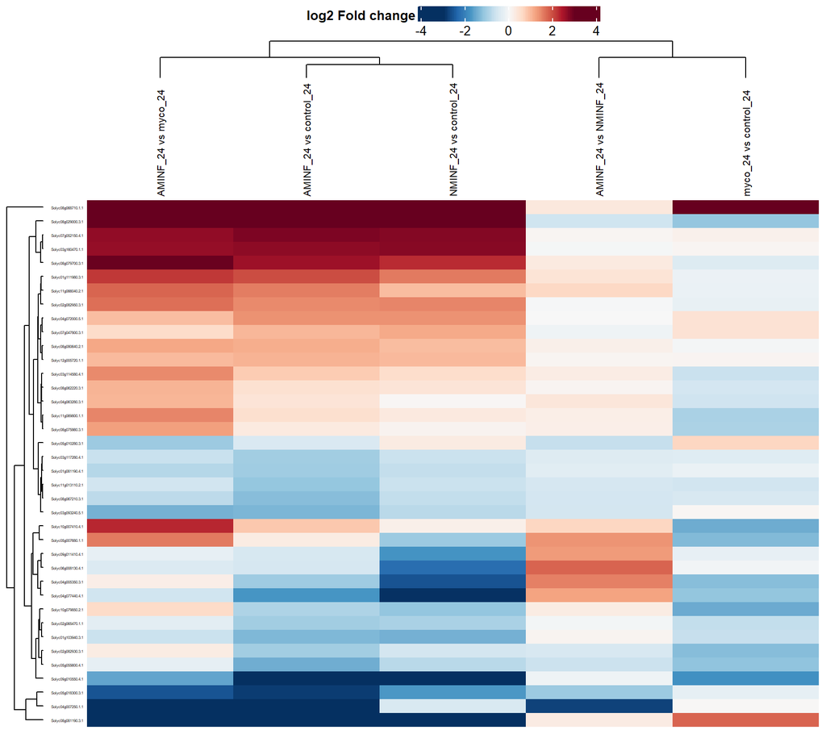

```r
plot_heatmap(dep = dep,
             type = 'contrast',
             col_limit = 3.0,
             row_font_size = 3,
             clustering_distance = 'gower',
             col_font_size = 8)
```

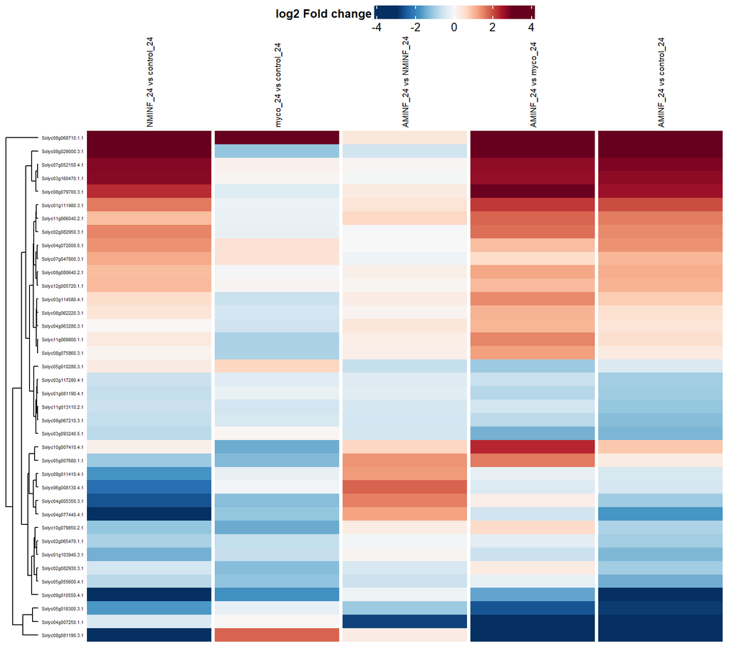

```r
# this plots only DE proteins
# see row_data <- SummarizedExperiment::rowData(dep, use.names = FALSE) in fiunction above
plot_heatmapX(dep = dep,
              type = 'contrast',
              col_limit = 3.0,
              row_font_size = 4,
              clustering_distance = 'gower',
              col_font_size = 7,
              column_split = c(1, 2, 3, 4, 5))
```

## 6.9 Volcano plots per contrast/comparison

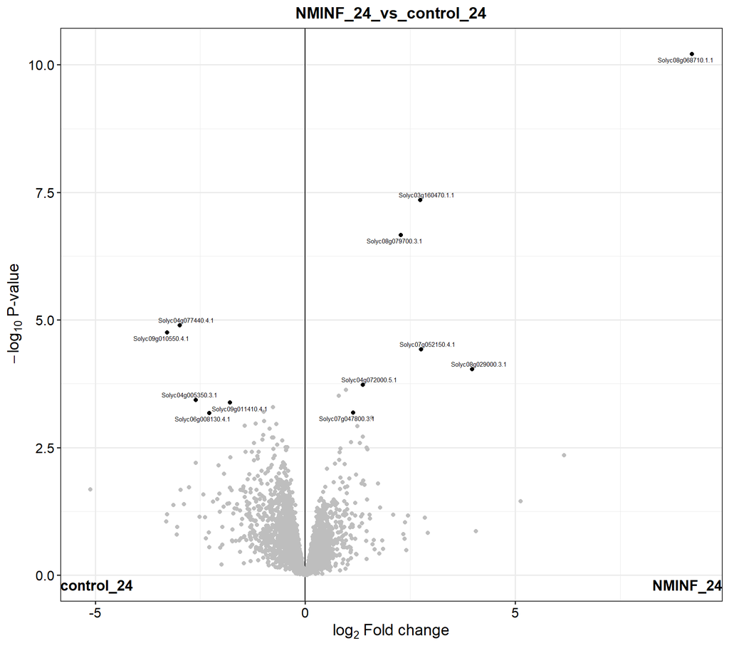

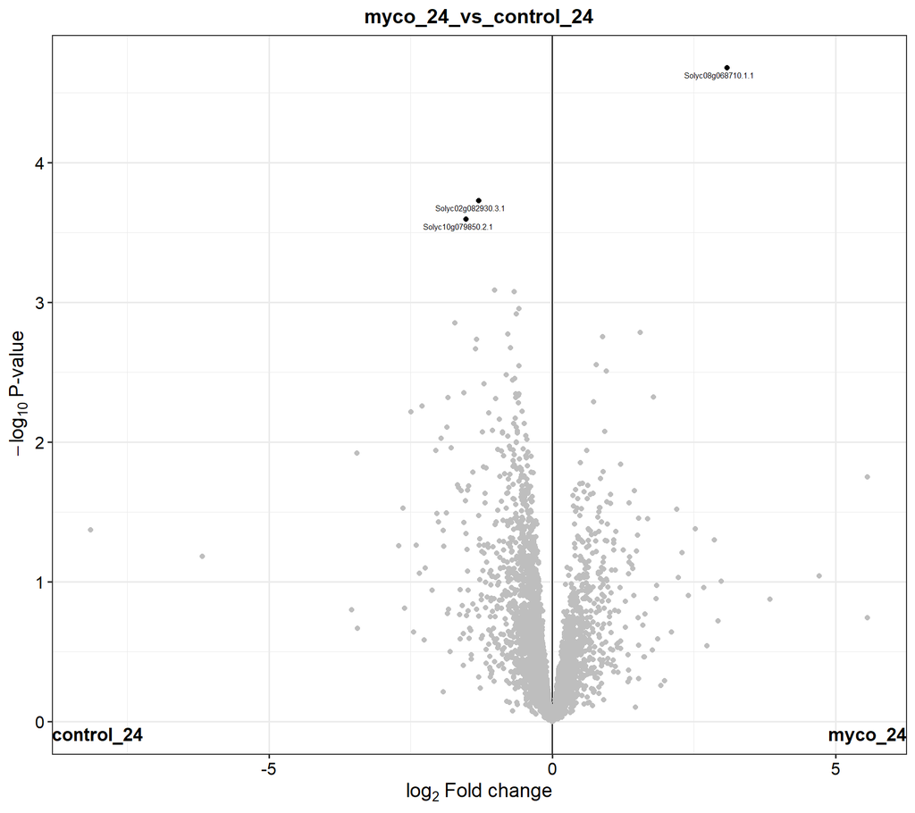

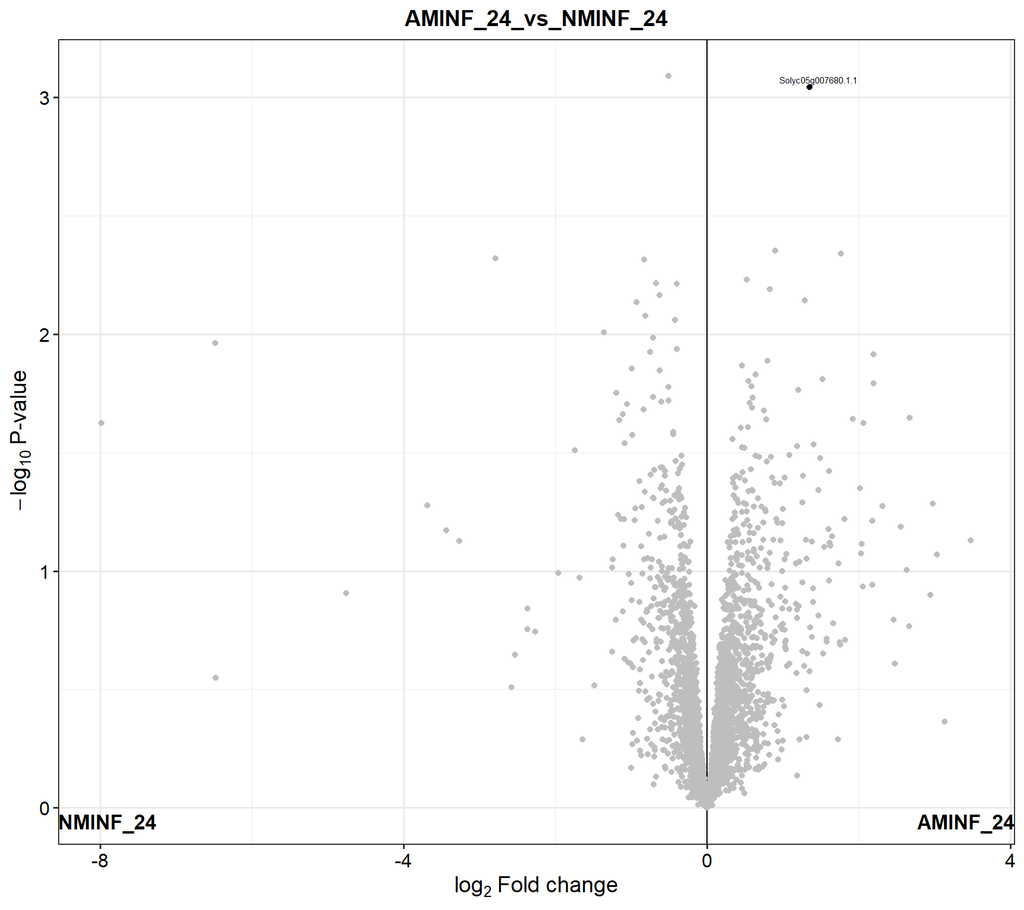

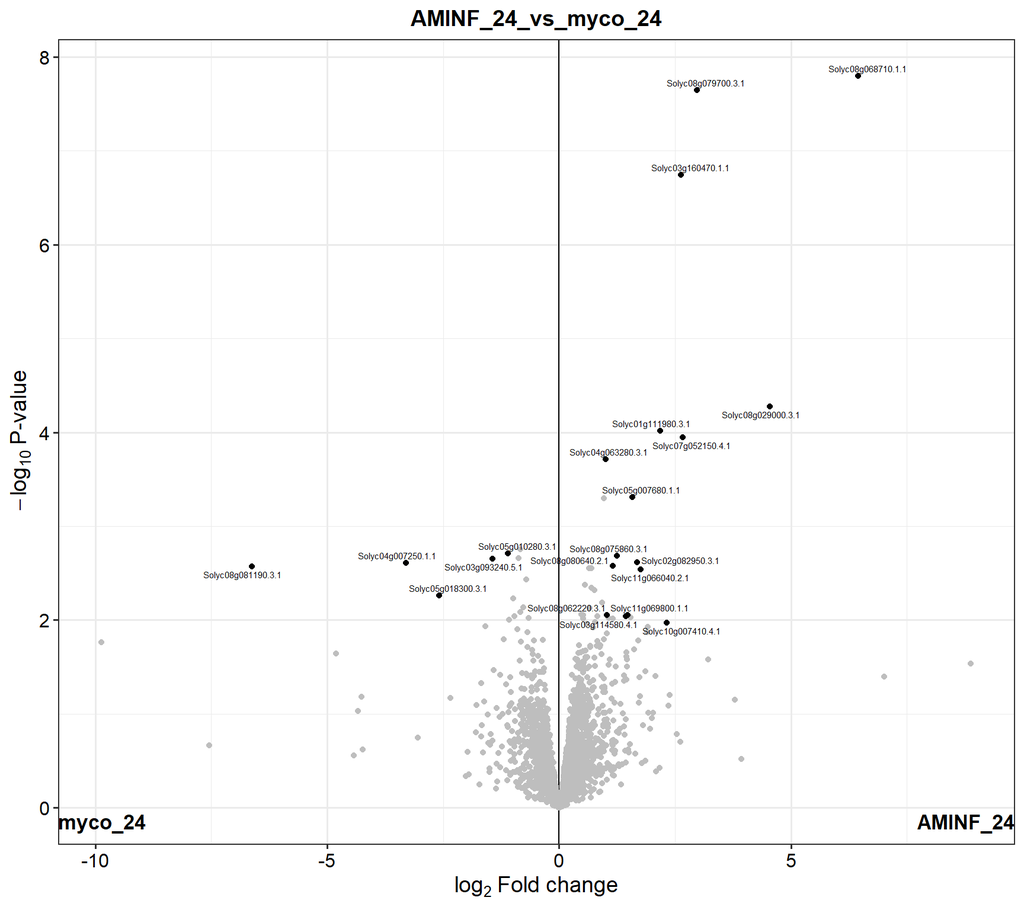

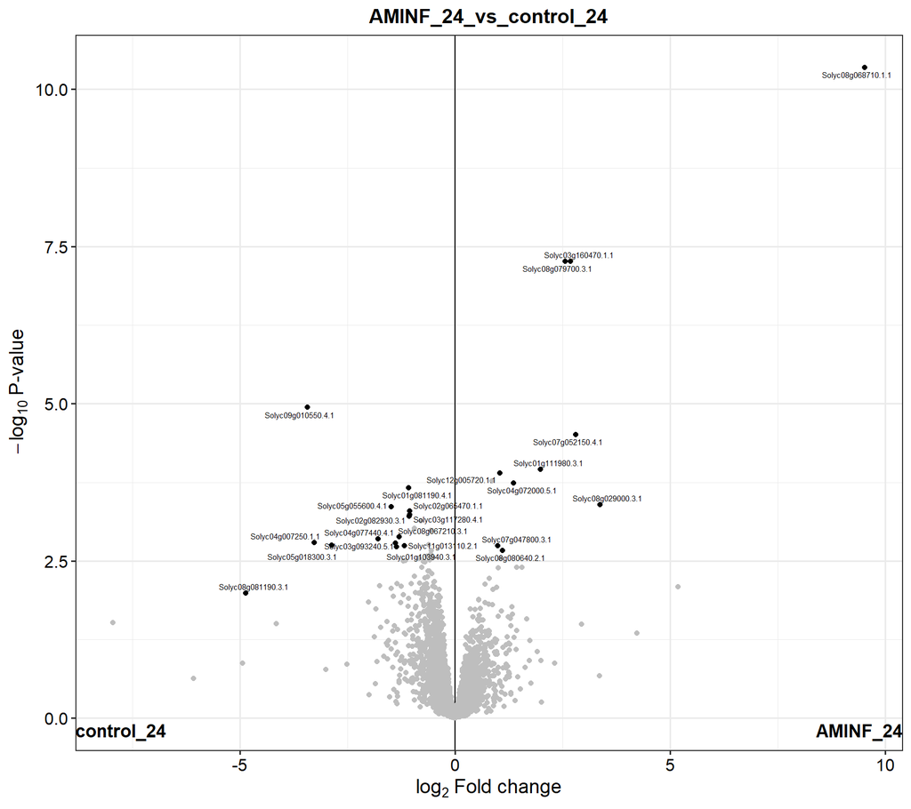

```r
plots = list()
cnt = 1
for (i in  mytest) {
  contrast = NULL
  assign('contrast', value = i)
  p = plot_volcano(dep, contrast = contrast, label_size = 2, add_names = TRUE)
  plots[[cnt]] = p
  cnt = cnt + 1
}

print(plots)
```

# 7 Plot frequency of significant conditions per protein and the overlap in proteins between conditions

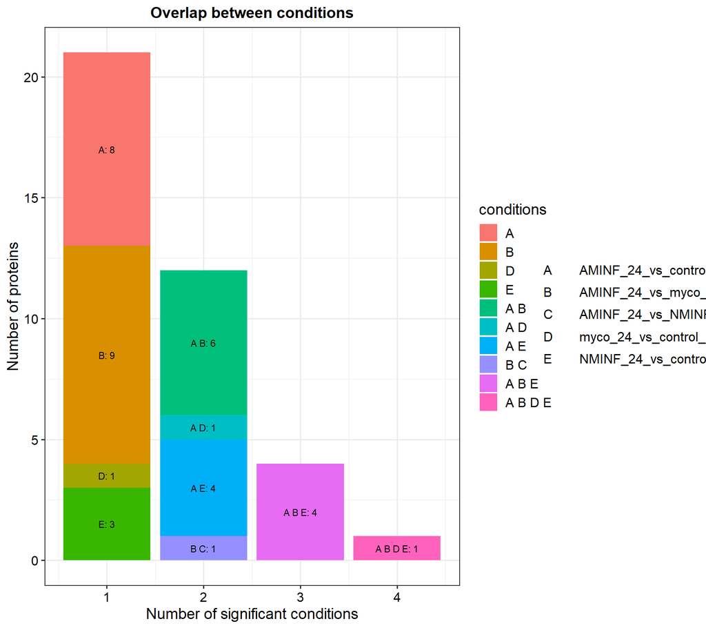

```r
# Plot frequency of significant conditions per protein and the overlap in proteins between conditions

plot_cond(dep)
```

## 7.1 Get results

```r
## ----results_table------------------------------------------------------------
# Generate a results table
data_results = get_results(dep)

# Number of significant proteins
data_results %>% dplyr::filter(significant) %>% nrow()
```

```
## [1] 38
```

```r
## ----results_table2-----------------------------------------------------------
# Column names of the results table
colnames(data_results)
```

```
##  [1] "name"                               "ID"
##  [3] "AMINF_24_vs_control_24_p.val"       "AMINF_24_vs_myco_24_p.val"
##  [5] "AMINF_24_vs_NMINF_24_p.val"         "myco_24_vs_control_24_p.val"
##  [7] "NMINF_24_vs_control_24_p.val"       "AMINF_24_vs_control_24_p.adj"
##  [9] "AMINF_24_vs_myco_24_p.adj"          "AMINF_24_vs_NMINF_24_p.adj"
## [11] "myco_24_vs_control_24_p.adj"        "NMINF_24_vs_control_24_p.adj"
## [13] "AMINF_24_vs_control_24_significant" "AMINF_24_vs_myco_24_significant"
## [15] "AMINF_24_vs_NMINF_24_significant"   "myco_24_vs_control_24_significant"
## [17] "NMINF_24_vs_control_24_significant" "significant"
## [19] "AMINF_24_vs_control_24_ratio"       "AMINF_24_vs_myco_24_ratio"
## [21] "AMINF_24_vs_NMINF_24_ratio"         "myco_24_vs_control_24_ratio"
## [23] "NMINF_24_vs_control_24_ratio"       "AMINF_24_centered"
## [25] "control_24_centered"                "myco_24_centered"
## [27] "NMINF_24_centered"
```

```r
# ## ----get_df-------------------------------------------------------------------
# # Generate a wide data.frame
# df_wide = get_df_wide(dep)
# # Generate a long data.frame
# df_long = get_df_long(dep)

# dt = pathwaysDF[, list(variables = paste(bin, collapse = " | ")), by = pID]
# data.table::setDF(dt)
# colnames(dt)[2] = 'BIN'
# colnames(dt)[1] = 'pID'
#
# colnames(data_results)[2] = 'pID'
#
# table(dt$pID %in% data_results$pID)
# table(data_results$pID %in% dt$pID)
# table(Prot$pID %in% data_results$pID)
# table(data_results$pID %in% Prot$pID)
#
# data_results = merge(dt, data_results, by = 'pID', all.x = FALSE, all.y = TRUE)
# data_results = merge(data_results, Prot, by = 'pID', all.x = TRUE, all.y = TRUE)



# fpi = file.path('..', 'output')
# fn = 'Prot.GMM_Ath.shortName.txt'
# sn = data.table::fread(file.path(fpi, fn), header = TRUE)
# data.table::setDF(sn)
# colnames(sn)[2] = 'pID'
#
# table(sn$pID %in% data_results$pID)
# table(data_results$pID %in% sn$pID)
#
# data_results = merge(data_results, sn, by = 'pID', all.x = TRUE, all.y = FALSE)


fpo = file.path('..', 'output')
fn = 'phosphoProteomics-DE-DEP.txt'

write.table(data_results,
            file = file.path(fpo, fn),
            append = FALSE,
            quote = FALSE,
            sep = "\t",
            eol = "\n",
            na = "-",
            dec = ".",
            row.names = FALSE,
            col.names = TRUE,
            qmethod = c("escape"),
            fileEncoding = "UTF-8")


fn = 'phosphoProteomics_filtered.txt'

write.table(data_norm@assays@data[[1]],
            file = file.path(fpo, fn),
            append = FALSE,
            quote = FALSE,
            sep = "\t",
            eol = "\n",
            na = "-",
            dec = ".",
            row.names = TRUE,
            col.names = TRUE,
            qmethod = c("escape"),
            fileEncoding = "UTF-8")
```

# 8 Gene set co-regulation

https://github.com/ctlab/fgsea

GESECA: multilevel Monte-Carlo variant for performing gene sets co-regulation analysis

GESECA takes as an input:

- E - gene expression matrix, where rows and columns correspond to genes and samples respectively
- P - list of gene sets

By default, GESECA method performs centering for rows of the matrix E. So, after that, the gene values are assumed to have zero mean

For each gene set p in P the gene set score : sum(colSums(E[p, ])**2) / length(p)

This score was inspired by the variance of principal components from the principal component analysis (PCA). Therefore, the given score can be viewed in terms of explained variance by the gene set p. Geometrically, this can be considered as an embedding of samples into a one-dimensional space, given by a unit vector in which nonzero positions correspond to genes from gene set p.

In the case of row-centered matrix E the variance of highly correlated genes is summed up to a higher score. While the genes that are not correlated cancel each other and the total gene set variance is low.

Read more at https://bioconductor.org/packages/release/bioc/vignettes/fgsea/inst/doc/geseca-tutorial.html

The value of center determines how column centering is performed. If center is a numeric-alike vector with length equal to the number of columns of x, then each column of x has the corresponding value from center subtracted from it. If center is TRUE then centering is done by subtracting the column means (omitting NAs) of x from their corresponding columns, and if center is FALSE, no centering is done.

The value of scale determines how column scaling is performed (after centering). If scale is a numeric-alike vector with length equal to the number of columns of x, then each column of x is divided by the corresponding value from scale. If scale is TRUE then scaling is done by dividing the (centered) columns of x by their standard deviations if center is TRUE, and the root mean square otherwise. If scale is FALSE, no scaling is done.

The root-mean-square for a (possibly centered) column is defined as sqrt(sum(x^2)/(n-1)), where x is a vector of the non-missing values and n is the number of non-missing values. In the case center = TRUE, this is the same as the standard deviation, but in general it is not. (To scale by the standard deviations without centering, use scale(x, center = FALSE, scale = apply(x, 2, sd, na.rm = TRUE)).)